# Risk Factor Analysis

## Outcome Variable

**Outcome Variable:** stunted

## Predictor Variables

**Intervention Variable:** tr

**Adjustment Set:**

unadjusted

## Stratifying Variables

The analysis was stratified on these variable(s):

- safeh20
- agecat
- studyid
- country

## Data Summary

| safeh20 | agecat | studyid | country | tr | stunted | n_cell | n |
| --- | --- | --- | --- | --- | --- | --- | --- |
| 1 | 6 months | ki1000125-AgaKhanUniv | PAKISTAN | Control | 0 | 251 | 691 |
| 1 | 6 months | ki1000125-AgaKhanUniv | PAKISTAN | Control | 1 | 122 | 691 |
| 1 | 6 months | ki1000125-AgaKhanUniv | PAKISTAN | Maternal | 0 | 239 | 691 |
| 1 | 6 months | ki1000125-AgaKhanUniv | PAKISTAN | Maternal | 1 | 79 | 691 |
| 1 | 24 months | ki1000125-AgaKhanUniv | PAKISTAN | Control | 0 | 0 | 3 |
| 1 | 24 months | ki1000125-AgaKhanUniv | PAKISTAN | Control | 1 | 1 | 3 |
| 1 | 24 months | ki1000125-AgaKhanUniv | PAKISTAN | Maternal | 0 | 1 | 3 |
| 1 | 24 months | ki1000125-AgaKhanUniv | PAKISTAN | Maternal | 1 | 1 | 3 |
| 1 | Birth | ki1000125-AgaKhanUniv | PAKISTAN | Control | 0 | 7 | 11 |
| 1 | Birth | ki1000125-AgaKhanUniv | PAKISTAN | Maternal | 0 | 4 | 11 |
| 1 | 6 months | ki1000304-VITAMIN-A | INDIA | Control | 0 | 811 | 2503 |
| 1 | 6 months | ki1000304-VITAMIN-A | INDIA | Control | 1 | 451 | 2503 |
| 1 | 6 months | ki1000304-VITAMIN-A | INDIA | VitA | 0 | 830 | 2503 |
| 1 | 6 months | ki1000304-VITAMIN-A | INDIA | VitA | 1 | 411 | 2503 |
| 0 | 6 months | ki1000304-VITAMIN-A | INDIA | Control | 0 | 2 | 5 |
| 0 | 6 months | ki1000304-VITAMIN-A | INDIA | Control | 1 | 1 | 5 |
| 0 | 6 months | ki1000304-VITAMIN-A | INDIA | VitA | 0 | 1 | 5 |
| 0 | 6 months | ki1000304-VITAMIN-A | INDIA | VitA | 1 | 1 | 5 |
| 1 | 6 months | ki1000304-ZnMort | INDIA | Control | 0 | 47 | 124 |
| 1 | 6 months | ki1000304-ZnMort | INDIA | Control | 1 | 24 | 124 |
| 1 | 6 months | ki1000304-ZnMort | INDIA | Zinc | 0 | 35 | 124 |
| 1 | 6 months | ki1000304-ZnMort | INDIA | Zinc | 1 | 18 | 124 |
| 1 | 24 months | ki1000304-ZnMort | INDIA | Control | 0 | 22 | 122 |
| 1 | 24 months | ki1000304-ZnMort | INDIA | Control | 1 | 42 | 122 |
| 1 | 24 months | ki1000304-ZnMort | INDIA | Zinc | 0 | 29 | 122 |
| 1 | 24 months | ki1000304-ZnMort | INDIA | Zinc | 1 | 29 | 122 |
| 1 | 6 months | ki1000304b-SAS-FoodSuppl | INDIA | Control | 0 | 43 | 355 |
| 1 | 6 months | ki1000304b-SAS-FoodSuppl | INDIA | Control | 1 | 47 | 355 |
| 1 | 6 months | ki1000304b-SAS-FoodSuppl | INDIA | Other | 0 | 161 | 355 |
| 1 | 6 months | ki1000304b-SAS-FoodSuppl | INDIA | Other | 1 | 104 | 355 |

[output cut: 114 more lines]

The following strata were considered:

- safeh20: 0, agecat: 24 months, studyid: ki1112895-Burkina Faso Zn, country: BURKINA FASO
- safeh20: 0, agecat: 24 months, studyid: ki1148112-iLiNS-DOSE, country: MALAWI
- safeh20: 0, agecat: 24 months, studyid: ki1148112-LCNI-5, country: MALAWI
- safeh20: 0, agecat: 24 months, studyid: kiGH5241-JiVitA-4, country: BANGLADESH
- safeh20: 0, agecat: 6 months, studyid: iLiNS_DYADM_LNS, country: MALAWI
- safeh20: 0, agecat: 6 months, studyid: ki1000304-VITAMIN-A, country: INDIA
- safeh20: 0, agecat: 6 months, studyid: ki1112895-Burkina Faso Zn, country: BURKINA FASO
- safeh20: 0, agecat: 6 months, studyid: ki1148112-iLiNS-DOSE, country: MALAWI
- safeh20: 0, agecat: 6 months, studyid: ki1148112-iLiNS-DYAD-M, country: MALAWI
- safeh20: 0, agecat: 6 months, studyid: ki1148112-LCNI-5, country: MALAWI
- safeh20: 0, agecat: 6 months, studyid: kiGH5241-JiVitA-3, country: BANGLADESH
- safeh20: 0, agecat: 6 months, studyid: kiGH5241-JiVitA-4, country: BANGLADESH
- safeh20: 0, agecat: Birth, studyid: kiGH5241-JiVitA-3, country: BANGLADESH
- safeh20: 1, agecat: 24 months, studyid: iLiNS_DYADM_LNS, country: MALAWI
- safeh20: 1, agecat: 24 months, studyid: ki1000125-AgaKhanUniv, country: PAKISTAN
- safeh20: 1, agecat: 24 months, studyid: ki1000304-ZnMort, country: INDIA
- safeh20: 1, agecat: 24 months, studyid: ki1017093b-PROVIDE, country: BANGLADESH
- safeh20: 1, agecat: 24 months, studyid: ki1112895-Burkina Faso Zn, country: BURKINA FASO
- safeh20: 1, agecat: 24 months, studyid: ki1148112-iLiNS-DOSE, country: MALAWI
- safeh20: 1, agecat: 24 months, studyid: ki1148112-iLiNS-DYAD-M, country: MALAWI
- safeh20: 1, agecat: 24 months, studyid: ki1148112-LCNI-5, country: MALAWI
- safeh20: 1, agecat: 24 months, studyid: kiGH5241-JiVitA-3, country: BANGLADESH
- safeh20: 1, agecat: 24 months, studyid: kiGH5241-JiVitA-4, country: BANGLADESH
- safeh20: 1, agecat: 6 months, studyid: iLiNS_DYADM_LNS, country: MALAWI
- safeh20: 1, agecat: 6 months, studyid: ki1000125-AgaKhanUniv, country: PAKISTAN
- safeh20: 1, agecat: 6 months, studyid: ki1000304-VITAMIN-A, country: INDIA
- safeh20: 1, agecat: 6 months, studyid: ki1000304-ZnMort, country: INDIA
- safeh20: 1, agecat: 6 months, studyid: ki1000304b-SAS-FoodSuppl, country: INDIA
- safeh20: 1, agecat: 6 months, studyid: ki1017093b-PROVIDE, country: BANGLADESH
- safeh20: 1, agecat: 6 months, studyid: ki1112895-Burkina Faso Zn, country: BURKINA FASO
- safeh20: 1, agecat: 6 months, studyid: ki1148112-iLiNS-DOSE, country: MALAWI
- safeh20: 1, agecat: 6 months, studyid: ki1148112-iLiNS-DYAD-M, country: MALAWI
- safeh20: 1, agecat: 6 months, studyid: ki1148112-LCNI-5, country: MALAWI
- safeh20: 1, agecat: 6 months, studyid: kiGH5241-JiVitA-3, country: BANGLADESH
- safeh20: 1, agecat: 6 months, studyid: kiGH5241-JiVitA-4, country: BANGLADESH
- safeh20: 1, agecat: Birth, studyid: ki1000125-AgaKhanUniv, country: PAKISTAN
- safeh20: 1, agecat: Birth, studyid: kiGH5241-JiVitA-3, country: BANGLADESH
- safeh20: 1, agecat: Birth, studyid: kiGH5241-JiVitA-4, country: BANGLADESH

### Dropped Strata

Some strata were dropped due to rare outcomes:

- safeh20: 1, agecat: 24 months, studyid: ki1000125-AgaKhanUniv, country: PAKISTAN
- safeh20: 1, agecat: Birth, studyid: ki1000125-AgaKhanUniv, country: PAKISTAN
- safeh20: 0, agecat: 6 months, studyid: ki1000304-VITAMIN-A, country: INDIA
- safeh20: 1, agecat: 6 months, studyid: ki1017093b-PROVIDE, country: BANGLADESH
- safeh20: 1, agecat: 24 months, studyid: ki1017093b-PROVIDE, country: BANGLADESH
- safeh20: 0, agecat: 6 months, studyid: ki1148112-iLiNS-DOSE, country: MALAWI
- safeh20: 0, agecat: 24 months, studyid: ki1148112-iLiNS-DOSE, country: MALAWI
- safeh20: 1, agecat: 24 months, studyid: ki1148112-iLiNS-DYAD-M, country: MALAWI
- safeh20: 0, agecat: 6 months, studyid: ki1148112-iLiNS-DYAD-M, country: MALAWI
- safeh20: 0, agecat: 24 months, studyid: ki1148112-LCNI-5, country: MALAWI
- safeh20: 0, agecat: Birth, studyid: kiGH5241-JiVitA-3, country: BANGLADESH
- safeh20: 0, agecat: 6 months, studyid: kiGH5241-JiVitA-3, country: BANGLADESH
- safeh20: 0, agecat: 6 months, studyid: kiGH5241-JiVitA-4, country: BANGLADESH
- safeh20: 0, agecat: 24 months, studyid: kiGH5241-JiVitA-4, country: BANGLADESH
- safeh20: 1, agecat: 24 months, studyid: iLiNS_DYADM_LNS, country: MALAWI
- safeh20: 0, agecat: 6 months, studyid: iLiNS_DYADM_LNS, country: MALAWI

## Methods Detail

We’re interested in the causal parameters $E[Y_a]$ for all values of $a \in \mathcal{A}$. These parameters represent the mean outcome if, possibly contrary to fact, we intervened to set all units to have $A=a$. Under the randomization and positivity assumptions, these are identified by the statistical parameters $\psi_a=E_W[E_{Y|A,W}(Y|A=a,W)]$. In addition, we’re interested in the mean of $Y$, $E[Y]$ under no intervention (the observed mean). We will estimate these parameters by using SuperLearner to fit the relevant likelihood factors – $E_{Y|A,W}(Y|A=a,W)$ and $p(A=a|W)$, and then updating our likelihood fit using a joint TMLE.

For unadjusted analyses ($W=\{\}$), initial likelihoods were estimated using Lrnr_glm to estimate the simple $E(Y|A)$ and Lrnr_mean to estimate $p(A)$. For adjusted analyses, a small library containing Lrnr_glmnet, Lrnr_xgboost, and Lrnr_mean was used.

Having estimated these parameters, we will then use the delta method to estimate relative risks and attributable risks relative to a prespecified baseline level of $A$.

[output not shown]

# Results Detail

## Results Plots

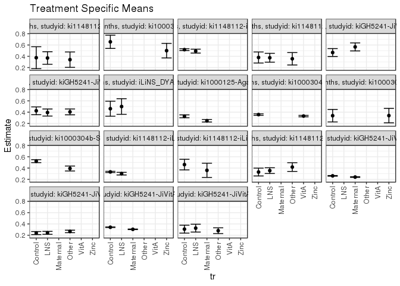

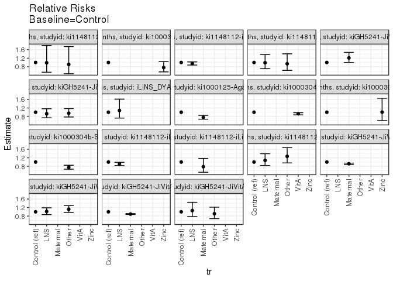

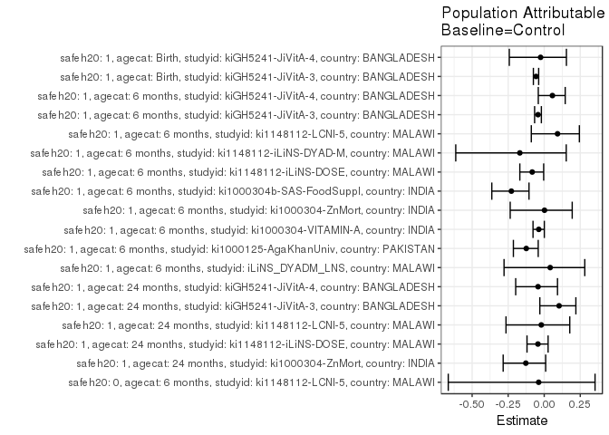

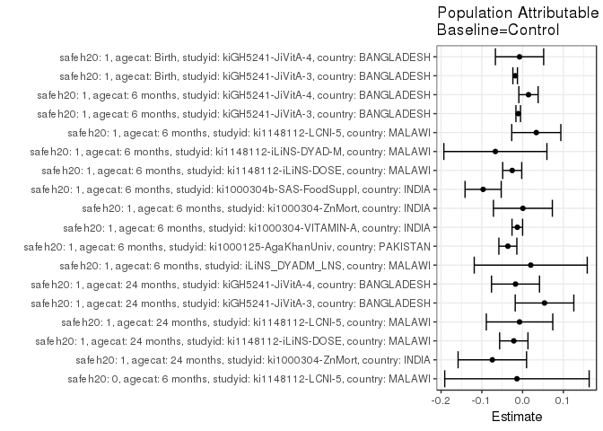

## Results Table

### Parameter: TSM

| safeh20 | agecat | studyid | country | intervention_level | baseline_level | estimate | ci_lower | ci_upper |
| --- | --- | --- | --- | --- | --- | --- | --- | --- |
| 0 | 6 months | ki1148112-LCNI-5 | MALAWI | Control | NA | 0.3750000 | 0.1806380 | 0.5693620 |
| 0 | 6 months | ki1148112-LCNI-5 | MALAWI | LNS | NA | 0.3698630 | 0.2587313 | 0.4809947 |
| 0 | 6 months | ki1148112-LCNI-5 | MALAWI | Other | NA | 0.3404255 | 0.2044830 | 0.4763681 |
| 1 | Birth | kiGH5241-JiVitA-3 | BANGLADESH | Control | NA | 0.3413907 | 0.3361336 | 0.3466477 |
| 1 | Birth | kiGH5241-JiVitA-3 | BANGLADESH | Maternal | NA | 0.3050020 | 0.2996439 | 0.3103601 |
| 1 | Birth | kiGH5241-JiVitA-4 | BANGLADESH | Control | NA | 0.3080357 | 0.2378939 | 0.3781775 |
| 1 | Birth | kiGH5241-JiVitA-4 | BANGLADESH | LNS | NA | 0.3259912 | 0.2564599 | 0.3955224 |
| 1 | Birth | kiGH5241-JiVitA-4 | BANGLADESH | Other | NA | 0.2803235 | 0.2294740 | 0.3311729 |
| 1 | 6 months | iLiNS_DYADM_LNS | MALAWI | Control | NA | 0.4615385 | 0.3285749 | 0.5945020 |
| 1 | 6 months | iLiNS_DYADM_LNS | MALAWI | LNS | NA | 0.5000000 | 0.3616072 | 0.6383928 |
| 1 | 6 months | ki1000125-AgaKhanUniv | PAKISTAN | Control | NA | 0.3270777 | 0.3013592 | 0.3527963 |
| 1 | 6 months | ki1000125-AgaKhanUniv | PAKISTAN | Maternal | NA | 0.2484277 | 0.2265559 | 0.2702994 |
| 1 | 6 months | ki1000304-VITAMIN-A | INDIA | Control | NA | 0.3573693 | 0.3440358 | 0.3707027 |
| 1 | 6 months | ki1000304-VITAMIN-A | INDIA | VitA | NA | 0.3311845 | 0.3181993 | 0.3441697 |
| 1 | 6 months | ki1000304-ZnMort | INDIA | Control | NA | 0.3380282 | 0.2275508 | 0.4485056 |
| 1 | 6 months | ki1000304-ZnMort | INDIA | Zinc | NA | 0.3396226 | 0.2116071 | 0.4676382 |
| 1 | 6 months | ki1000304b-SAS-FoodSuppl | INDIA | Control | NA | 0.5222222 | 0.4960227 | 0.5484218 |
| 1 | 6 months | ki1000304b-SAS-FoodSuppl | INDIA | Other | NA | 0.3924528 | 0.3485048 | 0.4364008 |
| 1 | 6 months | ki1148112-iLiNS-DOSE | MALAWI | Control | NA | 0.3317536 | 0.3208596 | 0.3426475 |
| 1 | 6 months | ki1148112-iLiNS-DOSE | MALAWI | LNS | NA | 0.3009804 | 0.2776469 | 0.3243139 |
| 1 | 6 months | ki1148112-iLiNS-DYAD-M | MALAWI | Control | NA | 0.4615385 | 0.3675859 | 0.5554910 |
| 1 | 6 months | ki1148112-iLiNS-DYAD-M | MALAWI | Maternal | NA | 0.3600000 | 0.2345512 | 0.4854488 |
| 1 | 6 months | ki1148112-LCNI-5 | MALAWI | Control | NA | 0.3295455 | 0.2600498 | 0.3990411 |
| 1 | 6 months | ki1148112-LCNI-5 | MALAWI | LNS | NA | 0.3550296 | 0.3039773 | 0.4060819 |
| 1 | 6 months | ki1148112-LCNI-5 | MALAWI | Other | NA | 0.4177215 | 0.3407639 | 0.4946792 |
| 1 | 6 months | kiGH5241-JiVitA-3 | BANGLADESH | Control | NA | 0.2619766 | 0.2561128 | 0.2678404 |
| 1 | 6 months | kiGH5241-JiVitA-3 | BANGLADESH | Maternal | NA | 0.2406202 | 0.2350636 | 0.2461768 |
| 1 | 6 months | kiGH5241-JiVitA-4 | BANGLADESH | Control | NA | 0.2387821 | 0.2116499 | 0.2659142 |
| 1 | 6 months | kiGH5241-JiVitA-4 | BANGLADESH | LNS | NA | 0.2426304 | 0.2167159 | 0.2685449 |
| 1 | 6 months | kiGH5241-JiVitA-4 | BANGLADESH | Other | NA | 0.2675676 | 0.2456408 | 0.2894943 |
| 1 | 24 months | ki1000304-ZnMort | INDIA | Control | NA | 0.6562500 | 0.5394074 | 0.7730926 |
| 1 | 24 months | ki1000304-ZnMort | INDIA | Zinc | NA | 0.5000000 | 0.3707914 | 0.6292086 |
| 1 | 24 months | ki1148112-iLiNS-DOSE | MALAWI | Control | NA | 0.5178571 | 0.5022126 | 0.5335017 |
| 1 | 24 months | ki1148112-iLiNS-DOSE | MALAWI | LNS | NA | 0.4918330 | 0.4571154 | 0.5265507 |
| 1 | 24 months | ki1148112-LCNI-5 | MALAWI | Control | NA | 0.3789474 | 0.2812393 | 0.4766554 |
| 1 | 24 months | ki1148112-LCNI-5 | MALAWI | LNS | NA | 0.3741497 | 0.2957999 | 0.4524994 |
| 1 | 24 months | ki1148112-LCNI-5 | MALAWI | Other | NA | 0.3561644 | 0.2461398 | 0.4661890 |
| 1 | 24 months | kiGH5241-JiVitA-3 | BANGLADESH | Control | NA | 0.4666667 | 0.3967870 | 0.5365463 |
| 1 | 24 months | kiGH5241-JiVitA-3 | BANGLADESH | Maternal | NA | 0.5660377 | 0.4951086 | 0.6369669 |
| 1 | 24 months | kiGH5241-JiVitA-4 | BANGLADESH | Control | NA | 0.4245614 | 0.3557302 | 0.4933926 |
| 1 | 24 months | kiGH5241-JiVitA-4 | BANGLADESH | LNS | NA | 0.3940397 | 0.3316967 | 0.4563827 |
| 1 | 24 months | kiGH5241-JiVitA-4 | BANGLADESH | Other | NA | 0.4051383 | 0.3537830 | 0.4564937 |

### Parameter: E(Y)

| safeh20 | agecat | studyid | country | intervention_level | baseline_level | estimate | ci_lower | ci_upper |
| --- | --- | --- | --- | --- | --- | --- | --- | --- |
| 0 | 6 months | ki1148112-LCNI-5 | MALAWI | NA | NA | 0.3611111 | 0.2823860 | 0.4398362 |
| 1 | Birth | kiGH5241-JiVitA-3 | BANGLADESH | NA | NA | 0.3230903 | 0.3154243 | 0.3307563 |
| 1 | Birth | kiGH5241-JiVitA-4 | BANGLADESH | NA | NA | 0.3004866 | 0.2649179 | 0.3360553 |
| 1 | 6 months | iLiNS_DYADM_LNS | MALAWI | NA | NA | 0.4814815 | 0.2894231 | 0.6735399 |
| 1 | 6 months | ki1000125-AgaKhanUniv | PAKISTAN | NA | NA | 0.2908828 | 0.2569951 | 0.3247704 |
| 1 | 6 months | ki1000304-VITAMIN-A | INDIA | NA | NA | 0.3443867 | 0.3257679 | 0.3630055 |
| 1 | 6 months | ki1000304-ZnMort | INDIA | NA | NA | 0.3387097 | 0.2550713 | 0.4223480 |
| 1 | 6 months | ki1000304b-SAS-FoodSuppl | INDIA | NA | NA | 0.4253521 | 0.3738504 | 0.4768538 |
| 1 | 6 months | ki1148112-iLiNS-DOSE | MALAWI | NA | NA | 0.3062551 | 0.2804956 | 0.3320146 |
| 1 | 6 months | ki1148112-iLiNS-DYAD-M | MALAWI | NA | NA | 0.3947368 | 0.2372395 | 0.5522342 |
| 1 | 6 months | ki1148112-LCNI-5 | MALAWI | NA | NA | 0.3630952 | 0.3267092 | 0.3994812 |
| 1 | 6 months | kiGH5241-JiVitA-3 | BANGLADESH | NA | NA | 0.2511950 | 0.2430674 | 0.2593226 |
| 1 | 6 months | kiGH5241-JiVitA-4 | BANGLADESH | NA | NA | 0.2531831 | 0.2388346 | 0.2675315 |
| 1 | 24 months | ki1000304-ZnMort | INDIA | NA | NA | 0.5819672 | 0.4940832 | 0.6698512 |
| 1 | 24 months | ki1148112-iLiNS-DOSE | MALAWI | NA | NA | 0.4962293 | 0.4581423 | 0.5343163 |
| 1 | 24 months | ki1148112-LCNI-5 | MALAWI | NA | NA | 0.3714286 | 0.3179847 | 0.4248725 |
| 1 | 24 months | kiGH5241-JiVitA-3 | BANGLADESH | NA | NA | 0.5204082 | 0.4200084 | 0.6208080 |
| 1 | 24 months | kiGH5241-JiVitA-4 | BANGLADESH | NA | NA | 0.4071363 | 0.3727269 | 0.4415458 |

### Parameter: RR

| safeh20 | agecat | studyid | country | intervention_level | baseline_level | estimate | ci_lower | ci_upper |
| --- | --- | --- | --- | --- | --- | --- | --- | --- |
| 0 | 6 months | ki1148112-LCNI-5 | MALAWI | Control | Control | 1.0000000 | 1.0000000 | 1.0000000 |
| 0 | 6 months | ki1148112-LCNI-5 | MALAWI | LNS | Control | 0.9863014 | 0.5417841 | 1.7955313 |
| 0 | 6 months | ki1148112-LCNI-5 | MALAWI | Other | Control | 0.9078014 | 0.4718839 | 1.7464114 |
| 1 | Birth | kiGH5241-JiVitA-3 | BANGLADESH | Control | Control | 1.0000000 | 1.0000000 | 1.0000000 |
| 1 | Birth | kiGH5241-JiVitA-3 | BANGLADESH | Maternal | Control | 0.8934106 | 0.8727770 | 0.9145320 |
| 1 | Birth | kiGH5241-JiVitA-4 | BANGLADESH | Control | Control | 1.0000000 | 1.0000000 | 1.0000000 |
| 1 | Birth | kiGH5241-JiVitA-4 | BANGLADESH | LNS | Control | 1.0582902 | 0.7746526 | 1.4457813 |
| 1 | Birth | kiGH5241-JiVitA-4 | BANGLADESH | Other | Control | 0.9100355 | 0.6801878 | 1.2175531 |
| 1 | 6 months | iLiNS_DYADM_LNS | MALAWI | Control | Control | 1.0000000 | 1.0000000 | 1.0000000 |
| 1 | 6 months | iLiNS_DYADM_LNS | MALAWI | LNS | Control | 1.0833333 | 0.7265391 | 1.6153447 |
| 1 | 6 months | ki1000125-AgaKhanUniv | PAKISTAN | Control | Control | 1.0000000 | 1.0000000 | 1.0000000 |
| 1 | 6 months | ki1000125-AgaKhanUniv | PAKISTAN | Maternal | Control | 0.7595371 | 0.6749688 | 0.8547010 |
| 1 | 6 months | ki1000304-VITAMIN-A | INDIA | Control | Control | 1.0000000 | 1.0000000 | 1.0000000 |
| 1 | 6 months | ki1000304-VITAMIN-A | INDIA | VitA | Control | 0.9267292 | 0.8779048 | 0.9782690 |
| 1 | 6 months | ki1000304-ZnMort | INDIA | Control | Control | 1.0000000 | 1.0000000 | 1.0000000 |
| 1 | 6 months | ki1000304-ZnMort | INDIA | Zinc | Control | 1.0047170 | 0.6100649 | 1.6546701 |
| 1 | 6 months | ki1000304b-SAS-FoodSuppl | INDIA | Control | Control | 1.0000000 | 1.0000000 | 1.0000000 |
| 1 | 6 months | ki1000304b-SAS-FoodSuppl | INDIA | Other | Control | 0.7515054 | 0.6647234 | 0.8496172 |
| 1 | 6 months | ki1148112-iLiNS-DOSE | MALAWI | Control | Control | 1.0000000 | 1.0000000 | 1.0000000 |
| 1 | 6 months | ki1148112-iLiNS-DOSE | MALAWI | LNS | Control | 0.9072409 | 0.8339848 | 0.9869317 |
| 1 | 6 months | ki1148112-iLiNS-DYAD-M | MALAWI | Control | Control | 1.0000000 | 1.0000000 | 1.0000000 |
| 1 | 6 months | ki1148112-iLiNS-DYAD-M | MALAWI | Maternal | Control | 0.7800000 | 0.5209863 | 1.1677850 |
| 1 | 6 months | ki1148112-LCNI-5 | MALAWI | Control | Control | 1.0000000 | 1.0000000 | 1.0000000 |
| 1 | 6 months | ki1148112-LCNI-5 | MALAWI | LNS | Control | 1.0773312 | 0.8346381 | 1.3905936 |
| 1 | 6 months | ki1148112-LCNI-5 | MALAWI | Other | Control | 1.2675687 | 0.9579853 | 1.6771974 |
| 1 | 6 months | kiGH5241-JiVitA-3 | BANGLADESH | Control | Control | 1.0000000 | 1.0000000 | 1.0000000 |
| 1 | 6 months | kiGH5241-JiVitA-3 | BANGLADESH | Maternal | Control | 0.9184797 | 0.8894069 | 0.9485029 |
| 1 | 6 months | kiGH5241-JiVitA-4 | BANGLADESH | Control | Control | 1.0000000 | 1.0000000 | 1.0000000 |
| 1 | 6 months | kiGH5241-JiVitA-4 | BANGLADESH | LNS | Control | 1.0161165 | 0.8693787 | 1.1876214 |
| 1 | 6 months | kiGH5241-JiVitA-4 | BANGLADESH | Other | Control | 1.1205514 | 0.9740644 | 1.2890683 |
| 1 | 24 months | ki1000304-ZnMort | INDIA | Control | Control | 1.0000000 | 1.0000000 | 1.0000000 |
| 1 | 24 months | ki1000304-ZnMort | INDIA | Zinc | Control | 0.7619048 | 0.5566890 | 1.0427705 |
| 1 | 24 months | ki1148112-iLiNS-DOSE | MALAWI | Control | Control | 1.0000000 | 1.0000000 | 1.0000000 |
| 1 | 24 months | ki1148112-iLiNS-DOSE | MALAWI | LNS | Control | 0.9497465 | 0.8795531 | 1.0255419 |
| 1 | 24 months | ki1148112-LCNI-5 | MALAWI | Control | Control | 1.0000000 | 1.0000000 | 1.0000000 |
| 1 | 24 months | ki1148112-LCNI-5 | MALAWI | LNS | Control | 0.9873394 | 0.7082868 | 1.3763337 |
| 1 | 24 months | ki1148112-LCNI-5 | MALAWI | Other | Control | 0.9398782 | 0.6285209 | 1.4054760 |
| 1 | 24 months | kiGH5241-JiVitA-3 | BANGLADESH | Control | Control | 1.0000000 | 1.0000000 | 1.0000000 |
| 1 | 24 months | kiGH5241-JiVitA-3 | BANGLADESH | Maternal | Control | 1.2129380 | 0.9978297 | 1.4744185 |
| 1 | 24 months | kiGH5241-JiVitA-4 | BANGLADESH | Control | Control | 1.0000000 | 1.0000000 | 1.0000000 |
| 1 | 24 months | kiGH5241-JiVitA-4 | BANGLADESH | LNS | Control | 0.9281101 | 0.7397913 | 1.1643668 |
| 1 | 24 months | kiGH5241-JiVitA-4 | BANGLADESH | Other | Control | 0.9542515 | 0.7768732 | 1.1721293 |

### Parameter: PAR

| safeh20 | agecat | studyid | country | intervention_level | baseline_level | estimate | ci_lower | ci_upper |
| --- | --- | --- | --- | --- | --- | --- | --- | --- |
| 0 | 6 months | ki1148112-LCNI-5 | MALAWI | Control | NA | -0.0138889 | -0.1910386 | 0.1632608 |
| 1 | Birth | kiGH5241-JiVitA-3 | BANGLADESH | Control | NA | -0.0183004 | -0.0239006 | -0.0127001 |
| 1 | Birth | kiGH5241-JiVitA-4 | BANGLADESH | Control | NA | -0.0075491 | -0.0667305 | 0.0516323 |
| 1 | 6 months | iLiNS_DYADM_LNS | MALAWI | Control | NA | 0.0199430 | -0.1186468 | 0.1585328 |
| 1 | 6 months | ki1000125-AgaKhanUniv | PAKISTAN | Control | NA | -0.0361950 | -0.0582614 | -0.0141285 |
| 1 | 6 months | ki1000304-VITAMIN-A | INDIA | Control | NA | -0.0129825 | -0.0259778 | 0.0000128 |
| 1 | 6 months | ki1000304-ZnMort | INDIA | Control | NA | 0.0006815 | -0.0715933 | 0.0729563 |
| 1 | 6 months | ki1000304b-SAS-FoodSuppl | INDIA | Control | NA | -0.0968701 | -0.1412098 | -0.0525304 |
| 1 | 6 months | ki1148112-iLiNS-DOSE | MALAWI | Control | NA | -0.0254985 | -0.0488410 | -0.0021560 |
| 1 | 6 months | ki1148112-iLiNS-DYAD-M | MALAWI | Control | NA | -0.0668016 | -0.1932070 | 0.0596038 |
| 1 | 6 months | ki1148112-LCNI-5 | MALAWI | Control | NA | 0.0335498 | -0.0266480 | 0.0937475 |
| 1 | 6 months | kiGH5241-JiVitA-3 | BANGLADESH | Control | NA | -0.0107816 | -0.0164230 | -0.0051401 |
| 1 | 6 months | kiGH5241-JiVitA-4 | BANGLADESH | Control | NA | 0.0144010 | -0.0092212 | 0.0380232 |
| 1 | 24 months | ki1000304-ZnMort | INDIA | Control | NA | -0.0742828 | -0.1582600 | 0.0096945 |
| 1 | 24 months | ki1148112-iLiNS-DOSE | MALAWI | Control | NA | -0.0216279 | -0.0563535 | 0.0130977 |
| 1 | 24 months | ki1148112-LCNI-5 | MALAWI | Control | NA | -0.0075188 | -0.0890338 | 0.0739962 |
| 1 | 24 months | kiGH5241-JiVitA-3 | BANGLADESH | Control | NA | 0.0537415 | -0.0181280 | 0.1256110 |
| 1 | 24 months | kiGH5241-JiVitA-4 | BANGLADESH | Control | NA | -0.0174251 | -0.0762774 | 0.0414272 |

### Parameter: PAF

| safeh20 | agecat | studyid | country | intervention_level | baseline_level | estimate | ci_lower | ci_upper |
| --- | --- | --- | --- | --- | --- | --- | --- | --- |
| 0 | 6 months | ki1148112-LCNI-5 | MALAWI | Control | NA | -0.0384615 | -0.6655437 | 0.3525223 |
| 1 | Birth | kiGH5241-JiVitA-3 | BANGLADESH | Control | NA | -0.0566416 | -0.0751364 | -0.0384650 |
| 1 | Birth | kiGH5241-JiVitA-4 | BANGLADESH | Control | NA | -0.0251229 | -0.2421633 | 0.1539945 |
| 1 | 6 months | iLiNS_DYADM_LNS | MALAWI | Control | NA | 0.0414201 | -0.2786250 | 0.2813566 |
| 1 | 6 months | ki1000125-AgaKhanUniv | PAKISTAN | Control | NA | -0.1244315 | -0.2138125 | -0.0416322 |
| 1 | 6 months | ki1000304-VITAMIN-A | INDIA | Control | NA | -0.0376975 | -0.0776311 | 0.0007562 |
| 1 | 6 months | ki1000304-ZnMort | INDIA | Control | NA | 0.0020121 | -0.2358992 | 0.1941253 |
| 1 | 6 months | ki1000304b-SAS-FoodSuppl | INDIA | Control | NA | -0.2277410 | -0.3634831 | -0.1055128 |
| 1 | 6 months | ki1148112-iLiNS-DOSE | MALAWI | Control | NA | -0.0832590 | -0.1691094 | -0.0037127 |
| 1 | 6 months | ki1148112-iLiNS-DYAD-M | MALAWI | Control | NA | -0.1692308 | -0.6135243 | 0.1527239 |
| 1 | 6 months | ki1148112-LCNI-5 | MALAWI | Control | NA | 0.0923994 | -0.0895101 | 0.2439365 |
| 1 | 6 months | kiGH5241-JiVitA-3 | BANGLADESH | Control | NA | -0.0429211 | -0.0666282 | -0.0197409 |
| 1 | 6 months | kiGH5241-JiVitA-4 | BANGLADESH | Control | NA | 0.0568798 | -0.0411079 | 0.1456450 |
| 1 | 24 months | ki1000304-ZnMort | INDIA | Control | NA | -0.1276408 | -0.2846843 | 0.0102051 |
| 1 | 24 months | ki1148112-iLiNS-DOSE | MALAWI | Control | NA | -0.0435845 | -0.1192431 | 0.0269598 |
| 1 | 24 months | ki1148112-LCNI-5 | MALAWI | Control | NA | -0.0202429 | -0.2651031 | 0.1772247 |
| 1 | 24 months | kiGH5241-JiVitA-3 | BANGLADESH | Control | NA | 0.1032680 | -0.0303704 | 0.2195735 |
| 1 | 24 months | kiGH5241-JiVitA-4 | BANGLADESH | Control | NA | -0.0427991 | -0.1978087 | 0.0921505 |